Marc Rexheuser  
Freight Management + Data Analysis  
0049.157.54090160 Email [LinkedIn](https://www.linkedin.com/in/marc-rexheuser/) de

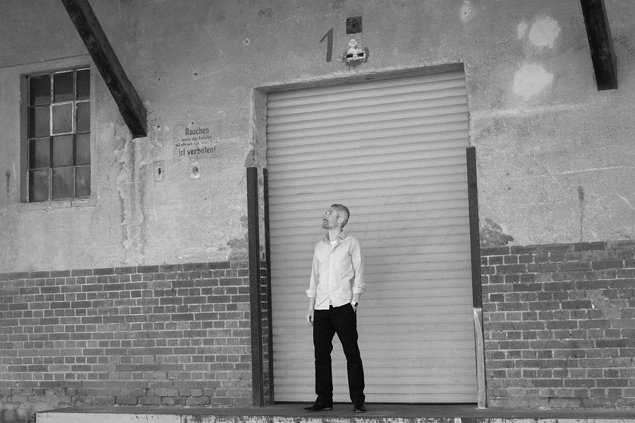

# Freight Management

## Old School

I know the international freight forwarding business from scratch. Too bad it’s so competitive and risky. But I’m good at it and I enjoy it professionally. I learned three things on my way:

- As an independent specialist, I am fully responsible. No finger-pointing when things become difficult - but thoughtful and consistent action. I have to understand individual shipper needs. And also the possible problems along transport chains with various logistics partners. I need to have an eye for the interfaces *and* a deep understanding of the real processes there.
- The logistics of my clients is only successful if goods are delivered on time, trouble-free and on budget. Contributing to this success requires momentum. The energy for this is part of my customer service.
- Transport processes are quickly assessed or criticized. It is even better to also recognize potential for improvement. With my experience, I also help *realise* this potential - i.e. saving money or improving service parameters.

## Low Tech High Touch Service

Low-value goods or high transport volumes cry out for automation and digital technology. This is not my world as a freight forwarder. Generally, I score with shippers of high-value goods. Especially when the digital connection of customers or supply structures would be senselessly expensive and complex, or simply not wanted. I make the difference in such a half-analog world. For example, by showing faster transport corridors. Or the ad hoc organisation of storage and consolidation sites.

## My offer

Freight pricing, operational implementation and documentation from a single source. For projects beyond pure freight coordination, I integrate a proven, personal logistics network. In this way storage and packaging solutions can also be realised. Geared towards exact individual needs, not according to the internal requirements and processes of a complex 3PL organisation. I certainly don’t have a fitting logistics solution for *every* shipper. But for *some* my solutions fit really well.

The platform I operate from is flexible. I can either act as a freight forwarder and thus also have commercial responsibility for freight management. Or I work as a freelancer for a limited period of time. Depending on what makes the most sense for the project, or also to meet internal customer requirements. In any case the desired logistical goal remains unaffected. I deliver transport solutions from strategy to operational implementation. Full stop.

# Data Analysis

## Traditional data mining

Data mining is the art and science of data analysis. I am more of a data artist than a scientist. Just as a good picture creates meaning for the viewer, I program data visualisations that are catchy. Best *all* relevant data points in *one* graphic, not distributed over 10 different reports. A table is enough wherever there is no need for colorful pictures. Interactive, too whenever it makes sense. So always looking for the simplest of all viable solutions. In other words: Graphical excellence is that which gives to the viewer the greatest number of ideas in the shortest time with the least ink in the smallest space.

Graham J. Williams, Director of Data Science at Microsoft, developer of Rattle

Edward R. Tufte, pioneer in the field of data visualisation in “The Visual Display of Quantitative Information”

The other side of this kind of creativity is neck-damaging computer work: from procurement of the raw data and its transformation to the design, validation and adaptation of data models. The more fundamental the resulting model, the easier it is to communicate knowledge. It is only by really *understanding* the analysed data that the model gets its value, not by its complexity. So my most common tools are clustering, decision trees and association analysis.

## Programming language vs. Business slang

As a data miner, I *translate* between the commercial managers and the database specialists. The managing director defines the problem or the specific question and the IT specialist knows where, how and which raw data is available. Organizationally, I have an intermediary role. On the one hand, I understand the operational processes and the overarching supply chain strategies. On the other hand, I recognise the value of the transaction data pit. And then I combine variables in certain ways in order to mine for data gold. For example in the form of:

- make error sources visible
- recognise trends
- make predictions
- define optimal distribution locations
- make complex, massive data statistically manageable
- visualize streams of goods geographically
- develop scorecards and online dashboards

## Cost-neutral use of software

For all analyses I use [R](https://www.r-project.org) with the development environment [RStudio](https://www.rstudio.com). Both are open source, free of charge and future-proof. Some of the biggest names in science, education and industry are active supporters of RStudio. For statistics and visualisation I use the [Tidyverse](https://www.tidyverse.org) package. I set up reproducible reports with [Rmarkdown](https://rmarkdown.rstudio.com/). For modeling I like [Rattle](https://rattle.togaware.com/), an independent software with an intuitive graphical user interface.

## Case studies

- Introduction of Diesel Surcharge, yes or no?
- Customer Segmentation deluxe
- Assess cooperation potential, just graphically
- Freight rate development, short and sweet

# CV

## Practice

**since 2008** self-employed, freelancer

- Planning and operational handling of all material and machinery transports for the new building of the German embassy in Mauritania (600 freight tons) on behalf of a working group
  - Risk analysis and transport insurance
  - Procurement of suitable shippers owned containers
  - Storage solution for the duration of the project
  - Just In Time empty container deliveries nationwide
  - Export customs clearance and documentation
  - Sea freight to Nouakchott
  - Return shipment and duty-free re-import of machines and tools
  - Within planned freight budget and time frame
- Speaker and workshop moderator at the ‘German Mongolian Logistics Days’ on the topic of horizontal logistics cooperation on behalf of the Gesellschaft für Internationale Zusammenarbeit GIZ, Ulan Bator
  - Creating awareness for logistics co-operations to improve efficiency
  - Further consultations in ministries and private companies
- Logistics advice and operational implementation of all material movements for an engineering company in the field of renewable energies
  - Transport organization for company relocation with tools and machines to Burundi
  - Logistics responsibility for all project exports
  - Purchase order follow up with suppliers across Europe
  - Cargo pick up and storage or consolidation for direct air and sea transport
  - Neutralisation measures
  - Sea and air freight to Burundi including import customs clearance and delivery to the construction site
- Planning and implementation of a cooperation between two forwarders in the area of national groupage cargo distribution
  - Data based customer segmentation
  - Fixed cost reduction and service improvement
  - Hands on work in operations for trouble-free adjustment of processes
- Freight rate purchasing and coordination of an ocean freight cross trade project (400 freight tons) from Bangladesh to Central Africa, on behalf of a freight forwarder

**2006-2010**

- Sole proprietor of an international trading business to finance studies - well-known customers such as Velux, DK or Dockwise Yacht Transport, US

**2005** Hellmann Worldwide Logistics, Brisbane

- Sales of sea, air and logistics services

**2003-2004** Hellmann Worldwide Logistics, Hamburg

- Development of own customer base and key account responsibility with a sales volume of € 7 million p.a.
- Transport project management for a factory relocation (door/door) from Germany to Iran, approx. 1200 freight tons
- Calculation and coordination for distribution projects across Europe, including sea freight from the Far East up to approx. 300 TEU
- Sales support for warehouse and assembly service operations

**2002** Hellmann Worldwide Logistics, Hamburg

- Sea freight export operations, Far East

**2001** Hellmann Worldwide Logistics, Sydney

- Traineeship Air freight export operations for perishable goods, as well as Sea freight export operations for general cargo

**2000** Federal Navy

- Basic training as material supplier and service in the area of warehouse logistics
- In and outbound warehouse operations for spare parts

**1999** TRANSCO Süd GmbH, Constance

- Customs declarant import, various customs procedures and product categories

## Theory

**2014 - 2015** Certificate courses

- SCM Fundamentals, Massachusetts Institute of Technology (MIT) via edX
- Supply Chain Design, Massachusetts Institute of Technology (MIT) via edX
- Foundations of Data Analysis with RStudio, University of Texas System via edX

**2006 - 2008** Business Economist in international transport logistics, studies at the German Foreign Trade and Transport Academy, Bremen

- Major Logistics and Marketing
- Award for the best thesis summer semester 2008 for the development of a Balanced Scorecard for the Hotel Logistics division at Kuehne + Nagel

**1996 - 1999** Forwarding agent, vocational training at TRANSCO Süd GmbH, Constance

- Focus on (inter) national load and groupage cargo on various modes of transport as well as customs
- Chamber of Commerce scholarship Vocational Training
- Award as a finalist for best trainee in 1999 Upper Rhine - Lake Constance

## Focus areas

- International freight management
- Development of solutions for transport logistics
- Result orientation, from strategy to concrete action
- Statistical programming in R and data visualization

## Languages

- German, mother tongue
- English, business fluent
- Spanish, basic knowledge